# Week 4

*This week we follow through the examples in Exercise Set 4.*

```r
date()
```

```
## [1] "Mon Nov 27 17:17:11 2023"
```

### Step 1

Create this file and include it in `index.Rmd`.

### Step 2

> “Load the Boston data from the MASS package”

```r
# Load MASS package
library(MASS)
data("Boston")
```

> “Explore the structure and the dimensions of the data”

```r
str(Boston)
```

```
## 'data.frame':    506 obs. of  14 variables:
##  $ crim   : num  0.00632 0.02731 0.02729 0.03237 0.06905 ...
##  $ zn     : num  18 0 0 0 0 0 12.5 12.5 12.5 12.5 ...
##  $ indus  : num  2.31 7.07 7.07 2.18 2.18 2.18 7.87 7.87 7.87 7.87 ...
##  $ chas   : int  0 0 0 0 0 0 0 0 0 0 ...
##  $ nox    : num  0.538 0.469 0.469 0.458 0.458 0.458 0.524 0.524 0.524 0.524 ...
##  $ rm     : num  6.58 6.42 7.18 7 7.15 ...
##  $ age    : num  65.2 78.9 61.1 45.8 54.2 58.7 66.6 96.1 100 85.9 ...
##  $ dis    : num  4.09 4.97 4.97 6.06 6.06 ...
##  $ rad    : int  1 2 2 3 3 3 5 5 5 5 ...
##  $ tax    : num  296 242 242 222 222 222 311 311 311 311 ...
##  $ ptratio: num  15.3 17.8 17.8 18.7 18.7 18.7 15.2 15.2 15.2 15.2 ...
##  $ black  : num  397 397 393 395 397 ...
##  $ lstat  : num  4.98 9.14 4.03 2.94 5.33 ...
##  $ medv   : num  24 21.6 34.7 33.4 36.2 28.7 22.9 27.1 16.5 18.9 ...
```

```r
dim(Boston)
```

```
## [1] 506  14
```

> “Describe the dataset briefly, assuming the reader has no previous knowledge of it.”

The dataset comes from a study by Harrison and Rubinfeld (1978) on house prices in Boston suburbs. It’s commonly used for teaching stats (specifically regression analysis, often called “machine learning” these days) by examples of predicting real estate prices from a number of demographic and socio-economic factors. The dataset contains 506 observations (rows) and 13 predictor variables plus the dependent variable (`medv`, **med**ian **v**alue of owner-occupied homes). See [documentation](https://stat.ethz.ch/R-manual/R-devel/library/MASS/html/Boston.html).

### Step 3

> “Show a graphical overview of the data”

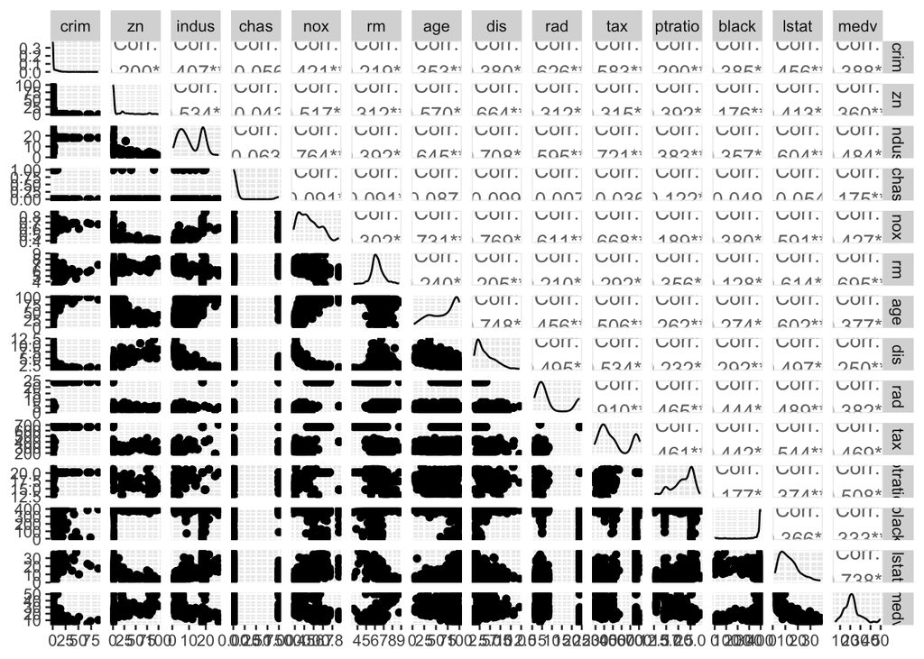

```r
library(GGally)
library(ggplot2)
library(dplyr)
p <- ggpairs(Boston)
p
```

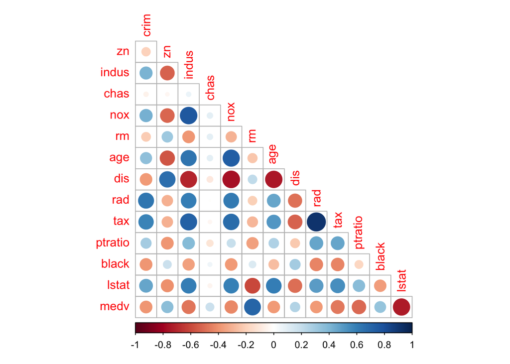

```r
cor_matrix <- cor(Boston) %>% round(digits = 2)
library(corrplot)
corrplot(cor_matrix, method="circle", diag = FALSE, type = 'lower')
```

> “Show summaries of the variables in the data”

```r
summary(Boston)
```

```
##       crim                zn             indus            chas
##  Min.   : 0.00632   Min.   :  0.00   Min.   : 0.46   Min.   :0.00000
##  1st Qu.: 0.08205   1st Qu.:  0.00   1st Qu.: 5.19   1st Qu.:0.00000
##  Median : 0.25651   Median :  0.00   Median : 9.69   Median :0.00000
##  Mean   : 3.61352   Mean   : 11.36   Mean   :11.14   Mean   :0.06917
##  3rd Qu.: 3.67708   3rd Qu.: 12.50   3rd Qu.:18.10   3rd Qu.:0.00000
##  Max.   :88.97620   Max.   :100.00   Max.   :27.74   Max.   :1.00000
##       nox               rm             age              dis
##  Min.   :0.3850   Min.   :3.561   Min.   :  2.90   Min.   : 1.130
##  1st Qu.:0.4490   1st Qu.:5.886   1st Qu.: 45.02   1st Qu.: 2.100
##  Median :0.5380   Median :6.208   Median : 77.50   Median : 3.207
##  Mean   :0.5547   Mean   :6.285   Mean   : 68.57   Mean   : 3.795
##  3rd Qu.:0.6240   3rd Qu.:6.623   3rd Qu.: 94.08   3rd Qu.: 5.188
##  Max.   :0.8710   Max.   :8.780   Max.   :100.00   Max.   :12.127
##       rad              tax           ptratio          black
##  Min.   : 1.000   Min.   :187.0   Min.   :12.60   Min.   :  0.32
##  1st Qu.: 4.000   1st Qu.:279.0   1st Qu.:17.40   1st Qu.:375.38
##  Median : 5.000   Median :330.0   Median :19.05   Median :391.44
##  Mean   : 9.549   Mean   :408.2   Mean   :18.46   Mean   :356.67
##  3rd Qu.:24.000   3rd Qu.:666.0   3rd Qu.:20.20   3rd Qu.:396.23
##  Max.   :24.000   Max.   :711.0   Max.   :22.00   Max.   :396.90
##      lstat            medv
##  Min.   : 1.73   Min.   : 5.00
##  1st Qu.: 6.95   1st Qu.:17.02
##  Median :11.36   Median :21.20
##  Mean   :12.65   Mean   :22.53
##  3rd Qu.:16.95   3rd Qu.:25.00
##  Max.   :37.97   Max.   :50.00
```

> “Describe and interpret the outputs, commenting on the distributions of the variables and the relationships between them.

Looking at the bottom row `medv` as an example, we can see that `rm` (“average number of rooms per dwelling”) is strongly positively correlated with `medv` and that `lstat` (“lower status of the population in %”) is strongly negatively correlated. This is not surprising simply from reading the variable descriptions, that is, they are re-stating intuitive claims such as “larger houses cost more”, “poor people live in cheap neighbourhoods”.

### Step 4

> “Standardize the dataset and print out summaries of the scaled data.”

```r
boston_scaled <- scale(Boston)
summary(boston_scaled)
```

```
##       crim                 zn               indus              chas
##  Min.   :-0.419367   Min.   :-0.48724   Min.   :-1.5563   Min.   :-0.2723
##  1st Qu.:-0.410563   1st Qu.:-0.48724   1st Qu.:-0.8668   1st Qu.:-0.2723
##  Median :-0.390280   Median :-0.48724   Median :-0.2109   Median :-0.2723
##  Mean   : 0.000000   Mean   : 0.00000   Mean   : 0.0000   Mean   : 0.0000
##  3rd Qu.: 0.007389   3rd Qu.: 0.04872   3rd Qu.: 1.0150   3rd Qu.:-0.2723
##  Max.   : 9.924110   Max.   : 3.80047   Max.   : 2.4202   Max.   : 3.6648
##       nox                rm               age               dis
##  Min.   :-1.4644   Min.   :-3.8764   Min.   :-2.3331   Min.   :-1.2658
##  1st Qu.:-0.9121   1st Qu.:-0.5681   1st Qu.:-0.8366   1st Qu.:-0.8049
##  Median :-0.1441   Median :-0.1084   Median : 0.3171   Median :-0.2790
##  Mean   : 0.0000   Mean   : 0.0000   Mean   : 0.0000   Mean   : 0.0000
##  3rd Qu.: 0.5981   3rd Qu.: 0.4823   3rd Qu.: 0.9059   3rd Qu.: 0.6617
##  Max.   : 2.7296   Max.   : 3.5515   Max.   : 1.1164   Max.   : 3.9566
##       rad               tax             ptratio            black
##  Min.   :-0.9819   Min.   :-1.3127   Min.   :-2.7047   Min.   :-3.9033
##  1st Qu.:-0.6373   1st Qu.:-0.7668   1st Qu.:-0.4876   1st Qu.: 0.2049
##  Median :-0.5225   Median :-0.4642   Median : 0.2746   Median : 0.3808
##  Mean   : 0.0000   Mean   : 0.0000   Mean   : 0.0000   Mean   : 0.0000
##  3rd Qu.: 1.6596   3rd Qu.: 1.5294   3rd Qu.: 0.8058   3rd Qu.: 0.4332
##  Max.   : 1.6596   Max.   : 1.7964   Max.   : 1.6372   Max.   : 0.4406
##      lstat              medv
##  Min.   :-1.5296   Min.   :-1.9063
##  1st Qu.:-0.7986   1st Qu.:-0.5989
##  Median :-0.1811   Median :-0.1449
##  Mean   : 0.0000   Mean   : 0.0000
##  3rd Qu.: 0.6024   3rd Qu.: 0.2683
##  Max.   : 3.5453   Max.   : 2.9865
```

> “How did the variables change?”

They are now how many standard deviations either side, general 0 to 3, 3+ being the extremes.

> “Create a categorical variable of the crime rate in the Boston dataset (from the scaled crime rate).”

```r
boston_scaled <- as.data.frame(boston_scaled)
boston_scaled$crim <- as.numeric(boston_scaled$crim)
bins <- quantile(boston_scaled$crim)
```

> “Use the quantiles as the break points in the categorical variable.”

```r
quantile_labels <- c("low", "med_low", "med_high", "high")
crime <- cut(boston_scaled$crim, breaks = bins, labels = quantile_labels, include.lowest = TRUE)
boston_scaled <- data.frame(boston_scaled, crime)
```

> “Drop the old crime rate variable from the dataset.”

```r
boston_scaled <- dplyr::select(boston_scaled, -crim)
```

> “Divide the dataset to train and test sets, so that 80% of the data belongs to the train set.”

```r
num_observations <- nrow(boston_scaled)
sample_ids <- sample(num_observations,  size = num_observations * 0.8)
train_set <- boston_scaled[sample_ids,]
test_set <- boston_scaled[-sample_ids,]
```

# Step 5

```r
# the function for lda biplot arrows
lda.arrows <- function(x, myscale = 1, arrow_heads = 0.1, color = "red", tex = 0.75, choices = c(1,2)){
  heads <- coef(x)
  graphics::arrows(x0 = 0, y0 = 0,
         x1 = myscale * heads[,choices[1]],
         y1 = myscale * heads[,choices[2]], col=color, length = arrow_heads)
  text(myscale * heads[,choices], labels = row.names(heads),
       cex = tex, col=color, pos=3)
}
```

> “Fit the linear discriminant analysis on the train set. Use the categorical crime rate as the target variable and all the other variables in the dataset as predictor variables.”

```r
# `crime` as the target variable, and "." (all the others) as predicators
lda.fit <- lda(crime ~ ., data = train_set)
classes <- as.numeric(train_set$crime)
```

> “Draw the LDA biplot.”

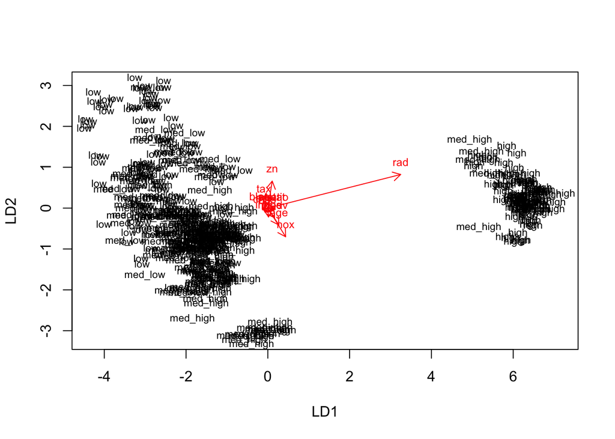

```r
plot(lda.fit, dimen = 2)
lda.arrows(lda.fit, myscale = 1)
```

### Step 6

> “Save the crime categories from the test set”

```r
correct_crime_level_predictions <- test_set$crime
```

> “Remove the categorical crime variable from the test dataset.”

```r
test_set <- dplyr::select(test_set, -crime)
```

> “Then predict the classes with the LDA model on the test data.”

```r
lda.pred <- predict(lda.fit, newdata = test_set)
```

> “Cross tabulate the results with the crime categories from the test set.”

```r
table(correct = correct_crime_level_predictions, predicted = lda.pred$class)
```

```
##           predicted
## correct    low med_low med_high high
##   low       12      12        3    0
##   med_low    5      18        4    0
##   med_high   0       8       14    1
##   high       0       0        0   25
```

> “Comment on the results.”

### Step 7

> “Reload the Boston dataset.”

```r
library(MASS)
data("Boston")
```

> “Scale the variables to get comparable distances.”

```r
boston_scaled <- scale(Boston)
```

> “Calculate the distances between the observations.”

```r
dist_eu <- dist(boston_scaled)
```

> “Run k-means algorithm on the dataset.”

```r
km <- kmeans(boston_scaled, centers = 4)
```

> “Investigate what is the optimal number of clusters and run the algorithm again.”

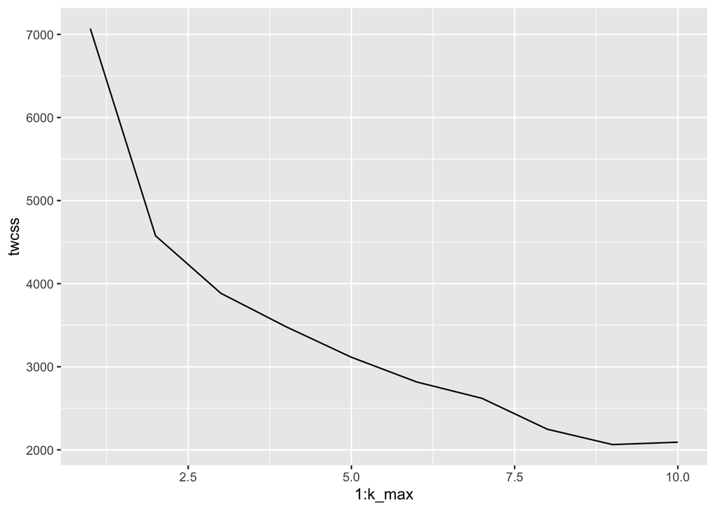

```r
set.seed(42)

k_max <- 10
twcss <- sapply(1:k_max, function(k){kmeans(boston_scaled, k)$tot.withinss})

# Spot the cliff
qplot(x = 1:k_max, y = twcss, geom = 'line')
```

> “Visualize the clusters”

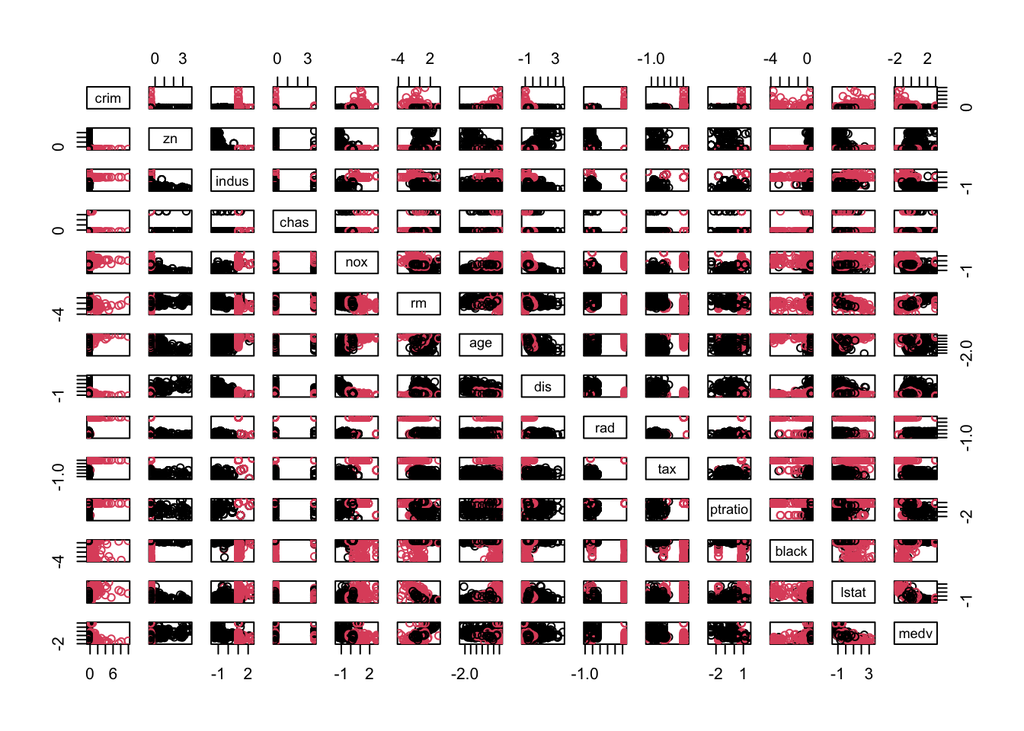

```r
km <- kmeans(boston_scaled, centers = 2)
pairs(boston_scaled, col = km$cluster)
```

> “Interpret the results”

The idea of clustering observations into groups is predicated on the notion that there are natural or hidden categories in the observations, namely, we could ask “how many types of suburbs are there?” The grouping is easily spotted visually when – for simplicity’s sake, let’s imagine two classes – two classes have metrics that are well away from each other. We can then see on a scatter plot that one group is over here in one corner, and the other group is way over there in an opposite corner. In terms referred to in the above steps, that there is a great distance between those two clouds. Here we have more than 2 dimensions, we have a dozen or so variables, but that’s not a problem for the machine, similar principles apply – that is, we try to find groups that have centres away from each other, all these dimensions considered. The chart is a bit hard to read but upon zooming it you could see that sometimes the groups are more distinct.

### Extra

> “Perform k-means on the original Boston data with some reasonable number of clusters (> 2).”

```r
km <- kmeans(boston_scaled, centers = 3)
```

> “Then perform LDA using the clusters as target classes.”

```r
cluster <- km$cluster
boston_scaled <- data.frame(boston_scaled, cluster)
```

```r
summary(boston_scaled)
```

```
##       crim                 zn               indus              chas
##  Min.   :-0.419367   Min.   :-0.48724   Min.   :-1.5563   Min.   :-0.2723
##  1st Qu.:-0.410563   1st Qu.:-0.48724   1st Qu.:-0.8668   1st Qu.:-0.2723
##  Median :-0.390280   Median :-0.48724   Median :-0.2109   Median :-0.2723
##  Mean   : 0.000000   Mean   : 0.00000   Mean   : 0.0000   Mean   : 0.0000
##  3rd Qu.: 0.007389   3rd Qu.: 0.04872   3rd Qu.: 1.0150   3rd Qu.:-0.2723
##  Max.   : 9.924110   Max.   : 3.80047   Max.   : 2.4202   Max.   : 3.6648
##       nox                rm               age               dis
##  Min.   :-1.4644   Min.   :-3.8764   Min.   :-2.3331   Min.   :-1.2658
##  1st Qu.:-0.9121   1st Qu.:-0.5681   1st Qu.:-0.8366   1st Qu.:-0.8049
##  Median :-0.1441   Median :-0.1084   Median : 0.3171   Median :-0.2790
##  Mean   : 0.0000   Mean   : 0.0000   Mean   : 0.0000   Mean   : 0.0000
##  3rd Qu.: 0.5981   3rd Qu.: 0.4823   3rd Qu.: 0.9059   3rd Qu.: 0.6617
##  Max.   : 2.7296   Max.   : 3.5515   Max.   : 1.1164   Max.   : 3.9566
##       rad               tax             ptratio            black
##  Min.   :-0.9819   Min.   :-1.3127   Min.   :-2.7047   Min.   :-3.9033
##  1st Qu.:-0.6373   1st Qu.:-0.7668   1st Qu.:-0.4876   1st Qu.: 0.2049
##  Median :-0.5225   Median :-0.4642   Median : 0.2746   Median : 0.3808
##  Mean   : 0.0000   Mean   : 0.0000   Mean   : 0.0000   Mean   : 0.0000
##  3rd Qu.: 1.6596   3rd Qu.: 1.5294   3rd Qu.: 0.8058   3rd Qu.: 0.4332
##  Max.   : 1.6596   Max.   : 1.7964   Max.   : 1.6372   Max.   : 0.4406
##      lstat              medv            cluster
##  Min.   :-1.5296   Min.   :-1.9063   Min.   :1.000
##  1st Qu.:-0.7986   1st Qu.:-0.5989   1st Qu.:1.000
##  Median :-0.1811   Median :-0.1449   Median :2.000
##  Mean   : 0.0000   Mean   : 0.0000   Mean   :1.941
##  3rd Qu.: 0.6024   3rd Qu.: 0.2683   3rd Qu.:3.000
##  Max.   : 3.5453   Max.   : 2.9865   Max.   :3.000
```

> “Visualize the results with a bi-plot.”

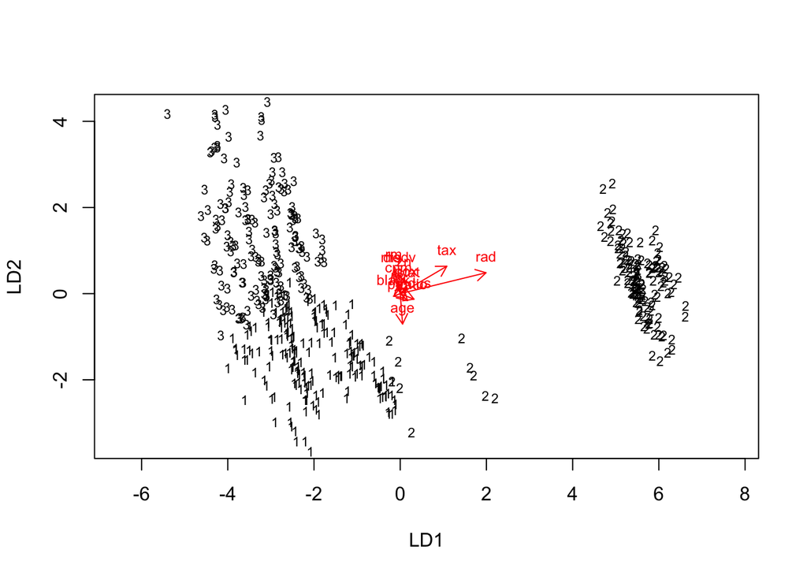

```r
lda.fit <- lda(cluster ~ ., data = boston_scaled[, -4])
plot(lda.fit, dimen = 2)
lda.arrows(lda.fit, myscale = 1)
```

> “Interpret the results. Which variables are the most influential linear separators for the clusters?”

#### Thank you and see you next week